# NFL Betting Trends — Against-the-Spread Performance Analysis

Sai

June 24, 2026

## Overview

This report analyzes NFL betting lines and final scores (Kaggle: *“NFL scores and betting data”*), reconstructing each game’s against-the-spread (ATS) and over/under result from the raw spread/total lines and the actual final score. It’s the R/dplyr companion to an Excel workbook covering the same dataset and the same derived columns — the logic below is a direct translation of that workbook’s `VLOOKUP` + nested-`IF` helper-column chain.

```r
nfl <- read.csv("/tmp/clean/nfl_clean.csv", stringsAsFactors = FALSE)
glimpse(nfl)
```

```
## Rows: 2,136
## Columns: 12
## $ Date           <chr> "09/09/2010", "09/12/2010", "09/12/2010", "09/12/2010",…
## $ Season         <int> 2010, 2010, 2010, 2010, 2010, 2010, 2010, 2010, 2010, 2…
## $ Week           <chr> "1", "1", "1", "1", "1", "1", "1", "1", "1", "1", "1", …
## $ HomeTeam       <chr> "New Orleans Saints", "Buffalo Bills", "Chicago Bears",…
## $ AwayTeam       <chr> "Minnesota Vikings", "Miami Dolphins", "Detroit Lions",…
## $ HomeScore      <int> 14, 10, 19, 34, 24, 38, 31, 20, 15, 31, 13, 17, 38, 13,…
## $ AwayScore      <int> 9, 15, 14, 24, 17, 24, 18, 27, 9, 6, 17, 14, 13, 7, 14,…
## $ FavoriteTeamID <chr> "NO", "MIA", "CHI", "IND", "JAX", "NE", "NYG", "GB", "A…
## $ SpreadFavorite <dbl> -5.0, -3.0, -6.5, -1.0, -3.0, -5.5, -6.0, -3.0, -1.5, -…
## $ OverUnderLine  <dbl> 49.5, 39.0, 45.0, 48.0, 41.5, 45.0, 41.0, 48.0, 39.5, 3…
## $ Stadium        <chr> "Louisiana Superdome", "Ralph Wilson Stadium", "Soldier…
## $ IsPlayoff      <chr> "False", "False", "False", "False", "False", "False", "…
```

## Team Name → Abbreviation Lookup

`FavoriteTeamID` uses team abbreviations; `HomeTeam`/`AwayTeam` use full names. There’s no shared key, so a lookup table is required either way. The Excel version uses `VLOOKUP` against a “Team Reference” sheet; here the same table is a named R vector used inside `recode()` — same join, different syntax. Note two franchises (Rams, Chargers) map old *and* new city names to one current abbreviation, because the betting data’s `FavoriteTeamID` already uses the current code even in old-city seasons — the same quirk documented in the Excel workbook’s lookup-table comment.

```r
team_ref <- c(
  "Arizona Cardinals" = "ARI", "Atlanta Falcons" = "ATL", "Baltimore Ravens" = "BAL",
  "Buffalo Bills" = "BUF", "Carolina Panthers" = "CAR", "Chicago Bears" = "CHI",
  "Cincinnati Bengals" = "CIN", "Cleveland Browns" = "CLE", "Dallas Cowboys" = "DAL",
  "Denver Broncos" = "DEN", "Detroit Lions" = "DET", "Green Bay Packers" = "GB",
  "Houston Texans" = "HOU", "Indianapolis Colts" = "IND", "Jacksonville Jaguars" = "JAX",
  "Kansas City Chiefs" = "KC", "Los Angeles Chargers" = "LAC", "Los Angeles Rams" = "LAR",
  "Miami Dolphins" = "MIA", "Minnesota Vikings" = "MIN", "New England Patriots" = "NE",
  "New Orleans Saints" = "NO", "New York Giants" = "NYG", "New York Jets" = "NYJ",
  "Oakland Raiders" = "OAK", "Philadelphia Eagles" = "PHI", "Pittsburgh Steelers" = "PIT",
  "San Diego Chargers" = "LAC", "San Francisco 49ers" = "SF", "Seattle Seahawks" = "SEA",
  "St. Louis Rams" = "LAR", "Tampa Bay Buccaneers" = "TB", "Tennessee Titans" = "TEN",
  "Washington Redskins" = "WAS"
)
```

## Deriving Game Results & ATS Outcome

Same five-step chain as the Excel “Raw Data” helper columns: `HomeAbbrev/AwayAbbrev` (lookup) → `FavoriteSide` (is the favorite home or away?) → `FavoriteMargin` (the favorite’s actual scoring margin, signed) → `ATSResult` (did the favorite’s margin beat the spread?) → `OUResult` (total points vs. the over/under line). `case_when()` is dplyr’s nested-`IF` equivalent — each clause is checked top to bottom, first match wins, exactly like Excel’s nested `IF()`.

```r
nfl <- nfl %>%
  mutate(
    HomeAbbrev = recode(HomeTeam, !!!team_ref),
    AwayAbbrev = recode(AwayTeam, !!!team_ref),
    Winner = case_when(
      HomeScore > AwayScore ~ HomeAbbrev,
      AwayScore > HomeScore ~ AwayAbbrev,
      TRUE ~ "Tie"
    ),
    HomeMargin = HomeScore - AwayScore,
    TotalPoints = HomeScore + AwayScore,
    FavoriteSide = case_when(
      FavoriteTeamID == HomeAbbrev ~ "Home",
      FavoriteTeamID == AwayAbbrev ~ "Away",
      FavoriteTeamID == "PICK" ~ "Pick",
      TRUE ~ "N/A"
    ),
    FavoriteMargin = case_when(
      FavoriteSide == "Home" ~ as.double(HomeMargin),
      FavoriteSide == "Away" ~ as.double(-HomeMargin),
      TRUE ~ NA_real_
    ),
    ATSResult = case_when(
      FavoriteSide == "Pick" ~ "No Line",
      is.na(FavoriteMargin) ~ "N/A",
      (FavoriteMargin + SpreadFavorite) > 0 ~ "Favorite Covered",
      (FavoriteMargin + SpreadFavorite) < 0 ~ "Underdog Covered",
      TRUE ~ "Push"
    ),
    OUResult = case_when(
      TotalPoints > OverUnderLine ~ "Over",
      TotalPoints < OverUnderLine ~ "Under",
      TRUE ~ "Push"
    )
  )

nfl %>% select(Season, HomeTeam, AwayTeam, FavoriteSide, ATSResult, OUResult) %>% head(8)
```

|  | Season | HomeTeam | AwayTeam | FavoriteSide | ATSResult | OUResult |
| --- | --- | --- | --- | --- | --- | --- |
| 1 | 2010 | New Orleans Saints | Minnesota Vikings | Home | Push | Under |
| 2 | 2010 | Buffalo Bills | Miami Dolphins | Away | Favorite Covered | Under |
| 3 | 2010 | Chicago Bears | Detroit Lions | Home | Underdog Covered | Under |
| 4 | 2010 | Houston Texans | Indianapolis Colts | Away | Underdog Covered | Over |
| 5 | 2010 | Jacksonville Jaguars | Denver Broncos | Home | Favorite Covered | Under |
| 6 | 2010 | New England Patriots | Cincinnati Bengals | Home | Favorite Covered | Over |
| 7 | 2010 | New York Giants | Carolina Panthers | Home | Favorite Covered | Over |
| 8 | 2010 | Philadelphia Eagles | Green Bay Packers | Away | Favorite Covered | Under |

## Season-Level ATS & Over/Under Rates

Mirrors the Excel “League Trends” sheet’s `COUNTIFS` (favorite-covers count and decided-games count, season by season) — `group_by(Season) %>% summarise()` does both counts in one pass instead of one `COUNTIFS` formula per outcome per season.

```r
season_summary <- nfl %>%
  group_by(Season) %>%
  summarise(
    Games = n(),
    Favorite_Covers = sum(ATSResult == "Favorite Covered"),
    Underdog_Covers = sum(ATSResult == "Underdog Covered"),
    Decided_ATS_Games = Favorite_Covers + Underdog_Covers,
    Favorite_Cover_Rate = if_else(Decided_ATS_Games == 0, NA_real_, Favorite_Covers / Decided_ATS_Games),
    Over_Count = sum(OUResult == "Over"),
    Decided_OU_Games = sum(OUResult %in% c("Over", "Under")),
    Over_Rate = if_else(Decided_OU_Games == 0, NA_real_, Over_Count / Decided_OU_Games),
    .groups = "drop"
  )

season_summary
```

| Season | Games | Favorite_Covers | Underdog_Covers | Decided_ATS_Games | Favorite_Cover_Rate | Over_Count | Decided_OU_Games | Over_Rate |
| --- | --- | --- | --- | --- | --- | --- | --- | --- |
| 2010 | 267 | 125 | 132 | 257 | 0.4863813 | 146 | 263 | 0.5551331 |
| 2011 | 267 | 121 | 136 | 257 | 0.4708171 | 130 | 262 | 0.4961832 |
| 2012 | 267 | 124 | 137 | 261 | 0.4750958 | 129 | 262 | 0.4923664 |
| 2013 | 267 | 129 | 126 | 255 | 0.5058824 | 133 | 261 | 0.5095785 |
| 2014 | 267 | 67 | 192 | 259 | 0.2586873 | 123 | 263 | 0.4676806 |
| 2015 | 267 | 113 | 140 | 253 | 0.4466403 | 124 | 263 | 0.4714829 |
| 2016 | 267 | 137 | 120 | 257 | 0.5330739 | 140 | 262 | 0.5343511 |
| 2017 | 267 | 128 | 126 | 254 | 0.5039370 | 121 | 266 | 0.4548872 |

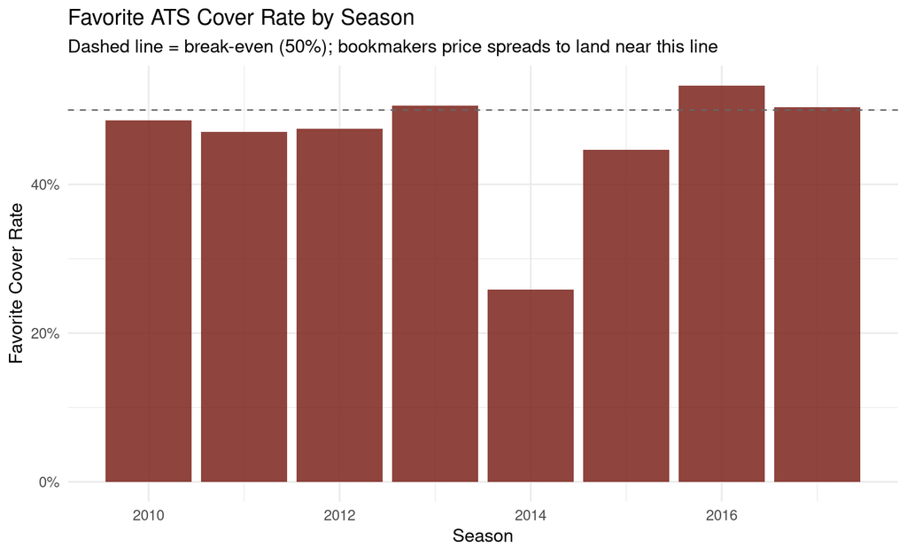

```r
ggplot(season_summary, aes(x = Season)) +
  geom_col(aes(y = Favorite_Cover_Rate), fill = "#7B241C", alpha = 0.85) +
  geom_hline(yintercept = 0.5, linetype = "dashed", color = "gray40") +
  scale_y_continuous(labels = scales::percent) +
  labs(title = "Favorite ATS Cover Rate by Season",
       subtitle = "Dashed line = break-even (50%); bookmakers price spreads to land near this line",
       x = "Season", y = "Favorite Cover Rate") +
  theme_minimal(base_size = 13)
```

## Per-Team ATS Record (Home + Away Combined)

Mirrors the Excel “Team ATS Records” sheet’s three-criteria `COUNTIFS` (team abbreviation + home/away side + ATS result), summed across both home and away appearances for each team.

```r
team_records <- bind_rows(
  nfl %>% filter(FavoriteSide == "Home") %>% transmute(Team = HomeAbbrev, ATSResult),
  nfl %>% filter(FavoriteSide == "Away") %>% transmute(Team = AwayAbbrev, ATSResult)
) %>%
  group_by(Team) %>%
  summarise(
    Times_Favored = n(),
    Covers = sum(ATSResult == "Favorite Covered"),
    Cover_Rate = Covers / Times_Favored,
    .groups = "drop"
  ) %>%
  filter(Times_Favored >= 20) %>%
  arrange(desc(Cover_Rate))

team_records
```

| Team | Times_Favored | Covers | Cover_Rate |
| --- | --- | --- | --- |
| NE | 124 | 70 | 0.5645161 |
| GB | 93 | 52 | 0.5591398 |
| SEA | 76 | 40 | 0.5263158 |
| SF | 63 | 33 | 0.5238095 |
| CIN | 69 | 35 | 0.5072464 |
| NO | 83 | 42 | 0.5060241 |
| HOU | 70 | 35 | 0.5000000 |
| MIN | 63 | 31 | 0.4920635 |
| PIT | 92 | 45 | 0.4891304 |
| KC | 72 | 35 | 0.4861111 |

[output cut: 22 more lines]

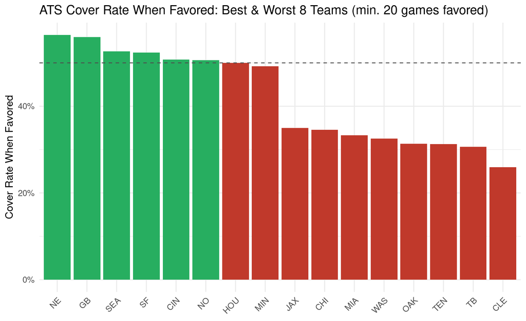

```r
top_bottom <- bind_rows(slice_head(team_records, n = 8), slice_tail(team_records, n = 8)) %>%
  mutate(Team = factor(Team, levels = Team))

ggplot(top_bottom, aes(x = Team, y = Cover_Rate, fill = Cover_Rate > 0.5)) +
  geom_col() +
  geom_hline(yintercept = 0.5, linetype = "dashed", color = "gray30") +
  scale_y_continuous(labels = scales::percent) +
  scale_fill_manual(values = c("TRUE" = "#27AE60", "FALSE" = "#C0392B"), guide = "none") +
  labs(title = "ATS Cover Rate When Favored: Best & Worst 8 Teams (min. 20 games favored)",
       x = NULL, y = "Cover Rate When Favored") +
  theme_minimal(base_size = 13) +
  theme(axis.text.x = element_text(angle = 45, hjust = 1))
```

## Spread Size vs. Outcome

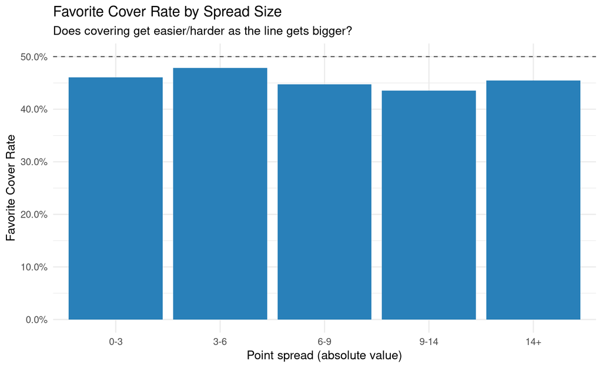

```r
nfl %>%
  filter(!is.na(SpreadFavorite)) %>%
  mutate(SpreadBucket = cut(abs(SpreadFavorite), breaks = c(0, 3, 6, 9, 14, Inf),
                             labels = c("0-3", "3-6", "6-9", "9-14", "14+"))) %>%
  filter(ATSResult %in% c("Favorite Covered", "Underdog Covered")) %>%
  group_by(SpreadBucket) %>%
  summarise(Games = n(), Favorite_Cover_Rate = mean(ATSResult == "Favorite Covered"), .groups = "drop") %>%
  ggplot(aes(x = SpreadBucket, y = Favorite_Cover_Rate)) +
  geom_col(fill = "#2980B9") +
  geom_hline(yintercept = 0.5, linetype = "dashed", color = "gray30") +
  scale_y_continuous(labels = scales::percent) +
  labs(title = "Favorite Cover Rate by Spread Size",
       subtitle = "Does covering get easier/harder as the line gets bigger?",
       x = "Point spread (absolute value)", y = "Favorite Cover Rate") +
  theme_minimal(base_size = 13)
```

*Data source: Kaggle — “NFL scores and betting data.”*